# Evaluating-data

## Step 3) Taxon cleaning

Here is where we findout if there are some taxa that shouldn’t be included in analysis, e.g. “Chloroplast / Cyanobacteria”. However, since these are landfill samples, I decided to keep everything

```r
get_taxa_unique(ps_all, "Domain")
```

```
## [1] "Bacteria" NA         "Archaea"
```

```r
get_taxa_unique(ps_all, "Phylum")
```

```
##  [1] "Firmicutes"       NA                 "Proteobacteria"   "Actinobacteriota"
##  [5] "Cyanobacteria"    "Bacteroidota"     "Deinococcota"     "Acidobacteriota"
##  [9] "Fusobacteriota"   "Crenarchaeota"    "Chloroflexi"      "Desulfobacterota"
```

```r
get_taxa_unique(ps_killed, "Domain")
```

```
## [1] "Bacteria" NA         "Archaea"
```

```r
get_taxa_unique(ps_killed, "Phylum")
```

```
##  [1] "Firmicutes"       NA                 "Proteobacteria"   "Actinobacteriota"
##  [5] "Deinococcota"     "Bacteroidota"     "Cyanobacteria"    "Acidobacteriota"
##  [9] "Chloroflexi"      "Patescibacteria"  "Fusobacteriota"   "Desulfobacterota"
## [13] "Bdellovibrionota" "Planctomycetota"  "Gemmatimonadota"  "Halobacterota"
```

## Step 4) Prevalence assesment

```r
#create a table for the number of features for each phyla

table(tax_table(ps_all)[, "Phylum"], exclude = NULL)
```

```
##
##  Acidobacteriota Actinobacteriota     Bacteroidota      Chloroflexi
##                3               33               11                1
##    Crenarchaeota    Cyanobacteria     Deinococcota Desulfobacterota
##                1                6                3                1
##       Firmicutes   Fusobacteriota   Proteobacteria             <NA>
##             1131                1              160              213
```

```r
#compute prevalence of each feature + store as a data frome; defined as the number of samples in which taxa appears at least once
prev_all <- apply(X = otu_table(ps_all), MARGIN = ifelse(taxa_are_rows(ps_all), yes = 1, no = 2), FUN = function(x){sum(x > 0)})

#add taxonomy and total read counts to this data frame
prev_all  <- data.frame(Prevalence = prev_all, TotalAbundance = taxa_sums(ps_all), tax_table(ps_all))

plyr::ddply(prev_all, "Phylum", function(df1){cbind(mean(df1$Prevalence),sum(df1$Prevalence))})
```

```
##              Phylum         1     2
## 1   Acidobacteriota  6.333333    19
## 2  Actinobacteriota 44.303030  1462
## 3      Bacteroidota  9.818182   108
## 4       Chloroflexi  6.000000     6
## 5     Crenarchaeota  8.000000     8
## 6     Cyanobacteria 24.000000   144
## 7      Deinococcota 20.333333    61
## 8  Desulfobacterota  7.000000     7
## 9        Firmicutes 42.511052 48080
## 10   Fusobacteriota  5.000000     5
## 11   Proteobacteria 35.912500  5746
## 12             <NA> 46.215962  9844
```

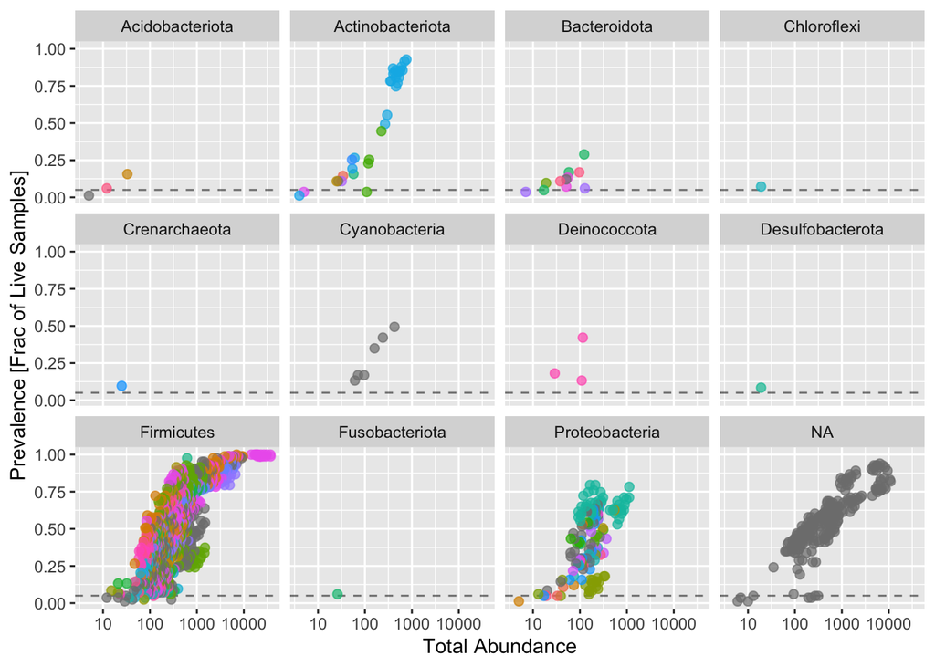

```r
#Dashed horizontal line is drawn at 5% prevalence level
#explore the relationship of prevalence and total read count for each feature
prev_all1 = subset(prev_all, Phylum %in% get_taxa_unique(ps_all, "Phylum"))

ggplot(prev_all1, aes(TotalAbundance, Prevalence / nsamples(ps_all),color=Family)) +
  geom_hline(yintercept = 0.05, alpha = 0.5, linetype = 2) + geom_point(size = 2, alpha = 0.7) +
  scale_x_log10() + xlab("Total Abundance") + ylab("Prevalence [Frac of Live Samples]") +
  facet_wrap(~Phylum) + theme(legend.position="none")
```

## Step 5) Prevalence filtering

This is how you filter if you wanted to filter at a ceratin prevelance.

```r
 nsamples(ps_all)
```

```
## [1] 83
```

```r
 prev_thres_all = 0.05 * nsamples(ps_all)
 prev_thres_all
```

```
## [1] 4.15
```

```r
 ntaxa(ps_all)
```

```
## [1] 1564
```

```r
keepTaxa_all <- rownames(prev_all)[(prev_all$Prevalence >= prev_thres_all)]


 ps_all.5 = prune_taxa(keepTaxa_all, ps_all)
 ntaxa(ps_all.5)
```

```
## [1] 1534
```

```r
 saveRDS(ps_all.5, "~/landfill-microcosms/data/live_samples_objects/ps_all.5")
```

# Transforming Data

We can use the `transform_sample_counts` function to transform the data with the OTU tables of the phyloseq objects directly. We can do a variety of different transformations on the phyloseq object. The `vst_all` phyloseq object already has transformed counts, so we would only do these transformations on the ps_all phyloseq object, or the untransformed data.

```r
ps_all.rl <- transform_sample_counts(ps_all, function(OTU) OTU/sum(OTU)) #relative abundances

ps_all.prop <- transform_sample_counts(ps_all, function(x) min(sample_sums(ps_all)) * x/sum(x))

ps_all.log <- transform_sample_counts(ps_all, function(x) log(1 + x))
```

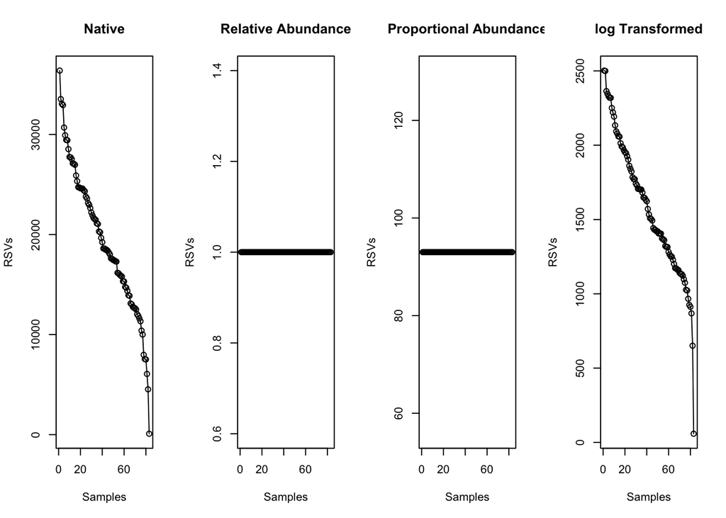

```r
par(mfrow=c(1,4))

plot(sort(sample_sums(ps_all), TRUE), type = "o", main = "Native", ylab = "RSVs", xlab = "Samples")

plot(sort(sample_sums(ps_all.rl), TRUE), type = "o", main = "Relative Abundance", ylab = "RSVs", xlab = "Samples")

plot(sort(sample_sums(ps_all.prop), TRUE), type = "o", main = "Proportional Abundance", ylab = "RSVs", xlab = "Samples")

plot(sort(sample_sums(ps_all.log), TRUE), type = "o", main ="log Transformed" , ylab = "RSVs", xlab = "Samples")
```

```r
par(mfrow=c(1,4))
```

RSVs = ASVs

```r
jpeg("~/landfill-microcosms/step-3-basic-data-vis/Figures/logtransformed_ps_all.jpg", width = 600, quality = 100)

p.nolog <- qplot(rowSums(otu_table(ps_all))) + ggtitle("Raw Counts") +
  theme_bw() +
  xlab("Row Sum") +
  ylab("# of Samples")

p.log <- qplot(log10(rowSums(otu_table(ps_all.log)))) +
  ggtitle("log10 transformed counts") +
  theme_bw() +
  xlab("Row Sum") +
  ylab("# of Samples")

ggarrange(p.nolog, p.log, ncol = 2, labels = c("A)", "B)"))
dev.off()
```

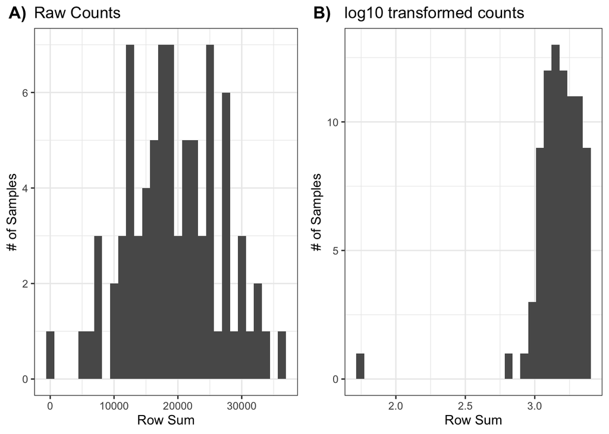

```r
ggarrange(p.nolog, p.log, ncol = 2, labels = c("A)", "B)"))
```

These data are more normal without the log transformation..

```r
ps_killed.rl <- transform_sample_counts(ps_killed, function(OTU) OTU/sum(OTU)) #relative abundances

ps_killed.prop <- transform_sample_counts(ps_killed, function(x) min(sample_sums(ps_all)) * x/sum(x))

ps_killed.log <- transform_sample_counts(ps_killed, function(x) log(1 + x))


jpeg("~/landfill-microcosms/step-3-basic-data-vis/Figures/logtransformed_ps_killed.jpg", width = 600, quality = 100)

p.nolog.killed <- qplot(rowSums(otu_table(ps_killed))) + ggtitle("Raw Counts") +
  theme_bw() +
  xlab("Row Sum") +
  ylab("# of Samples")

p.log.killed <- qplot(log10(rowSums(otu_table(ps_killed.log)))) +
  ggtitle("log10 transformed counts") +
  theme_bw() +
  xlab("Row Sum") +
  ylab("# of Samples")

ggarrange(p.nolog.killed, p.log.killed, ncol = 2, labels = c("A)", "B)"))
dev.off()
```

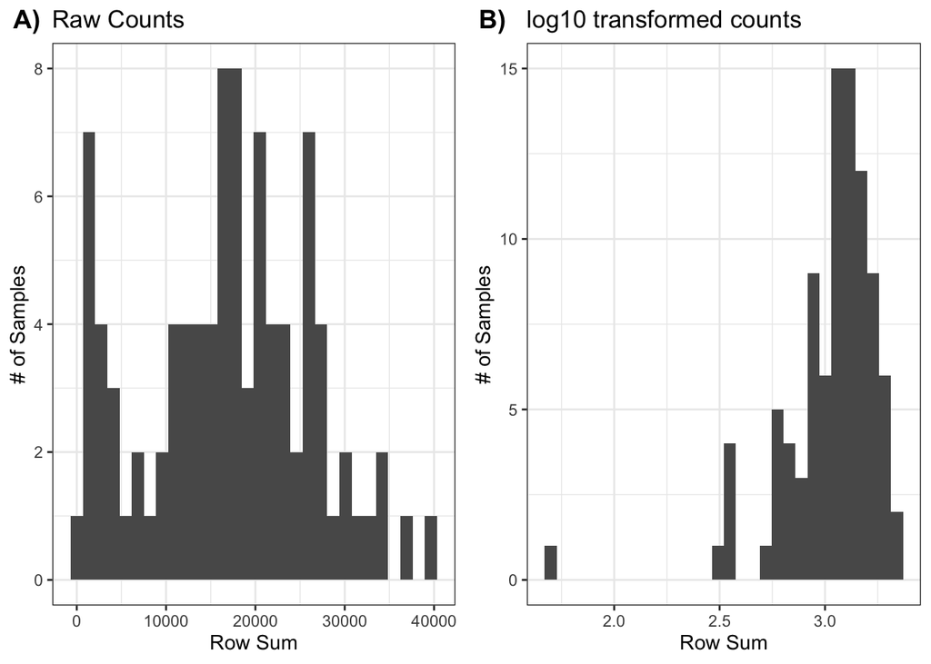

```r
ggarrange(p.nolog.killed, p.log.killed, ncol = 2, labels = c("A)", "B)"))
```

These are not normal either way

#save all objects to take to the next step

- outputs:
  - ps_all.step2
  - vst_all.step2
  - ps_all.rl
  - ps_all.prop
  - ps_killed.step2
  - vst_killed.step2
  - ps_killed.rl
  - ps_killed.prop

```r
# live samples

saveRDS(ps_all, "~/landfill-microcosms/data/live_samples_objects/ps_all.step2")

saveRDS(ps_all.rmout, "~/landfill-microcosms/data/live_samples_objects/ps_all.rmout") #outlier removed

saveRDS(vst_all, "~/landfill-microcosms/data/live_samples_objects/vst_all.step2")


saveRDS(ps_all.rl, "~/landfill-microcosms/data/live_samples_objects/ps_all.rl")

saveRDS(ps_all.prop, "~/landfill-microcosms/data/live_samples_objects/ps_all.prop")




 #killed samples

saveRDS(ps_killed, "~/landfill-microcosms/data/killed_microcosms_objects/ps_killed.step2")

saveRDS(ps_killed.rmout, "~/landfill-microcosms/data/killed_microcosms_objects/ps_killed.rmout")

saveRDS(vst_killed, "~/landfill-microcosms/data/killed_microcosms_objects/vst_killed.step2")

saveRDS(ps_killed.rl, "~/landfill-microcosms/data/killed_microcosms_objects/ps_killed.rl")

saveRDS(ps_killed.prop, "~/landfill-microcosms/data/killed_microcosms_objects/ps_killed.prop")
```